# Data Preprocessing

Lateral Analytics

May 26, 2017

## Data preprocessing for the Renthop (Two Sigma Connect) Kaggle Competition

https://www.kaggle.com/c/two-sigma-connect-rental-listing-inquiries

## Remove all objects

```r
rm(list = ls())
```

## Load libraries

```r
# Clear any previously loaded packages
pkgs_1 = names(sessionInfo()$otherPkgs)
pkgs_2 = paste('package:', pkgs_1, sep = "")
invisible(if (length(pkgs_1) > 0){
  lapply(pkgs_2, detach, character.only = TRUE, unload = TRUE)
})

library("tidyverse")
library("rjson")
library("rmarkdown")
library("lubridate")
library("ggplot2")
library("maps")
library("mapproj")
library("RColorBrewer")
library("wordcloud")
library("cluster")
library("stringr")
library("htmlwidgets")
## How to install rjava in preparation for syuzhet
## https://stackoverflow.com/questions/30572258/error-of-java-path-on-loading-rjava-package
library("syuzhet")
library("caret")
library("corrplot")
library("RANN")
```

## Load data

Load data files from previous .

```r
data <- readRDS(file = "../data/objects/data.rds")
listings_3 <- readRDS(file = "../data/objects/listings_3.rds")
```

## Prepare the data for modeling

### View listings in its current form

```r
str(listings_3)
```

```
## 'data.frame':    124011 obs. of  66 variables:
##  $ listing_id            : num  7170325 7092344 7158677 7211212 7225292 ...
##  $ bathrooms             : num  1 1 1 1.5 1 1 2 1 0 3 ...
##  $ bedrooms              : num  1 2 2 3 0 3 3 0 1 3 ...
##  $ building_id           : chr  "8579a0b0d54db803821a35a4a615e97a" "b8e75fc949a6cd8225b455648a951712" "cd759a988b8f23924b5a2058d5ab2b49" "53a5b119ba8f7b61d4e010512e0dfc85" ...
##  $ created               : chr  "2016-06-16 05:55:27" "2016-06-01 05:44:33" "2016-06-14 15:19:59" "2016-06-24 07:54:24" ...
##  $ description           : chr  "Spacious 1 Bedroom 1 Bathroom in Williamsburg!Apartment Features:- Renovated Eat in Kitchen With Dishwasher- Re"| __truncated__ "BRAND NEW GUT RENOVATED TRUE 2 BEDROOMFind yourself and your home in the center of it all. Steps from Grand Cen"| __truncated__ "**FLEX…
##  $ display_address       : chr  "145 Borinquen Place" "East 44th" "East 56th Street" "Metropolitan Avenue" ...
##  $ latitude              : num  40.7 40.8 40.8 40.7 40.7 ...
##  $ longitude             : num  -74 -74 -74 -73.9 -74 ...
##  $ manager_id            : chr  "a10db4590843d78c784171a107bdacb4" "955db33477af4f40004820b4aed804a0" "c8b10a317b766204f08e613cef4ce7a0" "5ba989232d0489da1b5f2c45f6688adc" ...
##  $ price                 : num  2400 3800 3495 3000 2795 ...
##  $ street_address        : chr  "145 Borinquen Place" "230 East 44th" "405 East 56th Street" "792 Metropolitan Avenue" ...
##  $ interest_level        : Factor w/ 3 levels "low","medium",..: 2 1 2 2 1 1 1 3 1 1 ...
##  $ section               : chr  "train" "train" "train" "train" ...
```

[output cut: 52 more lines]

### Replace NA values in “top_building” and “top_manager” with zero

```r
listings_3 <- listings_3 %>%
  mutate(top_manager = replace(top_manager, is.na(top_manager), 0),
         top_building = replace(top_building, is.na(top_building), 0))
```

### Remove fields that were used to create features, but can’t be directly modeled themselves

```r
listings_3 <- listings_3 %>%
  select(-description,
         -display_address,
         -street_address,
         -created,
         -dates_formatted,
         -created_ymd,
         -building_id,
         -manager_id)
```

listing_id is a label and should be removed

```r
listings_3 <- listings_3 %>%
  select(-listing_id)
```

### Reorder fields in preparation for modeling

```r
# Convert all categorical variables to factors
listings_3 <- listings_3 %>%
  mutate(section = factor(section),
  groups_agnes = factor(groups_agnes),
  groups_pam = factor(groups_pam),
  groups_clara = factor(groups_clara),
  created_dow = factor(created_dow),
  price_thresh = factor(price_thresh),
  price_room_thresh = factor(price_room_thresh),
  top_manager = factor(top_manager),
  top_building = factor(top_building),
  doorman = factor(doorman)
  )

# Order the fields by class
listings_3 <- listings_3 %>%
  select(order(sapply(listings_3,class)))

# Place the interest level, and section at the beginning
listings_3 <- listings_3 %>%
  select(interest_level, section, everything())
```

### Preprocess the data with the Caret preProcess function

View how the features are correlated with each other to better understand the data.

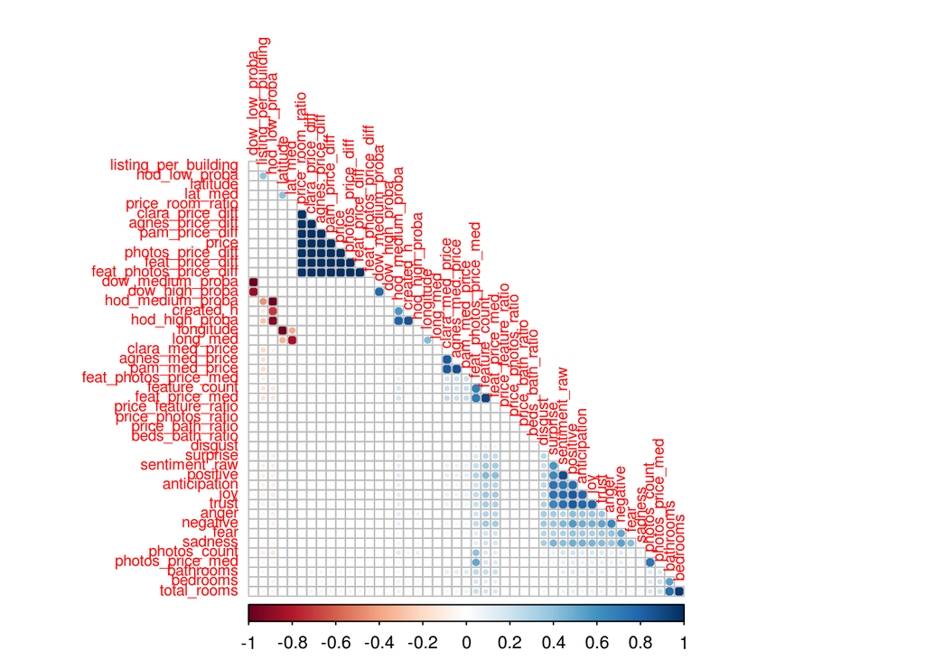

```r
correlations <- cor(listings_3[listings_3$section == "train",-c(1:11)])
# Replace NA values with 0 so the corrplot function will work
correlations[is.na(correlations)] <- 0

corrplot(correlations, order = "hclust", type = c("lower"), tl.cex=0.7, diag = FALSE)
```

A large cluster of positively correlated features is centered around various price difference measurements. This is intuitive. If an individual listing is particularly high or low it should have a large difference with a measure of median price. This should hold true for many different measures.

A second cluster of positively correlated features is found centered around the N.L.P. features. It also makes sense. Positive emotions are positively correlated with other positive emotions. The same relationship is found between various negative emotions.

There is a negatively correlated cluster that centers predominantly around the probability of being in one of the three interest levels. Obviously if the probability of one of them is high then the remaining two would need to be lower.

### Remove features that are highly correlated

The preProcess function from the caret package has a method called “corr”. It is supposed to filter out features with show a high correlation. For whatever reason when I used it in the next section an error occurred. After highly correlated features were removed the next method didn’t realize they had been removed. It tried to perform an operation on features which were no longer available.

For this reason, highly correlated features are identified and removed first before preProcess is called.

```r
high_corr <- findCorrelation(correlations, cutoff = 0.90)
high_corr_names <- colnames(correlations[,high_corr])

remaining_names <- names(listings_3)[!(names(listings_3) %in% high_corr_names)]
listings_3 <- listings_3[, remaining_names]
```

### Use preProcess from the caret package to remove zero variance features, transform, center, scale, and “examines the distribution of each predictor conditional on the outcome”.

```r
train_trans_data <- listings_3[listings_3$section == "train",-c(1,2)]
train_trans_outcome <- listings_3[listings_3$section == "train",1]

trans <- preProcess(train_trans_data,
                    method = c("YeoJohnson", "center", "scale", "knnImpute", "zv", "conditionalX"),
                    na.remove = TRUE, k = 5,
                    knnSummary = mean, outcome = train_trans_outcome,
                    verbose = TRUE,
                    cutoff = 0.90)
```

```
## Estimating Yeo-Johnson transformations for 33 predictors... applying them to training data
## Calculating 33 means for centering
## Calculating 33 standard deviations for scaling
```

Use the predict function to adjust listings_3 according to the calculations above. In a production environment this process would be used to adjust a new test set.

```r
listings_3_trans <- predict(trans, listings_3[,-c(1,2)])
listings_3_trans <- cbind(listings_3[,c(1,2)],listings_3_trans)
```

```r
saveRDS(listings_3, file = "../data/objects/listings_4.rds")
saveRDS(listings_3_trans, file = "../data/objects/listings_4_trans.rds")
```